# A Causal Framework for Regimen Forgiveness in HIV Treatment

## 13.10 Advanced Extensions: Monitoring, Censoring, and Switching

**Scope**

This section is **conceptual and illustrative**. It demonstrates how the LTMLE framework extends to handle informative monitoring, censoring, and treatment switching — complications that are ubiquitous in real HIV cohort data — but does not rerun the primary Monte Carlo study with these extensions. The code chunks below use an expanded DGP not generated in the main tutorial; they are included to show how the `ltmle` specification changes, not to produce new numerical results.

The primary analysis uses a simplified DGP where every patient’s outcome is directly observed, no one is lost to follow-up, and no one switches regimens. Real HIV cohorts involve all three complications. LTMLE accommodates each by expanding the node structure, introducing new estimand distinctions, and requiring additional modeling. We illustrate this using an expanded version of the same simulated cohort that adds informative monitoring ($M_t$), loss to follow-up ($C_t$), and treatment switching ($S_t$).

### 13.10.1 Extending to time-varying treatment: handling drug switching

The primary analysis above assumed that drug assignment is fixed at baseline: every patient remains on their initially randomised regimen throughout follow-up. In practice, clinicians frequently switch patients between ART regimens in response to virologic failure, intolerable side effects, or updated treatment guidelines. To accommodate treatment switching, we expand the treatment node structure. Instead of a single baseline drug assignment $A_0$ that is deterministically repeated at each block, each time point $t$ now has three A-nodes:

1. $A_{\text{drug},t}$ — binary indicator for the drug taken in block $t$ (1 = Drug A, 0 = Drug B)
2. $Z_{\text{med},t}$ — indicator for medium-or-higher adherence
3. $Z_{\text{high},t}$ — indicator for high adherence (structurally zero when $Z_{\text{med},t} = 0$)

The causal ordering within each block becomes $L_t \to A_{\text{drug},t} \to Z_{\text{med},t} \to Z_{\text{high},t} \to Y_t$, and the abar vector for a static regime now specifies the drug choice *and* adherence level at every time point. The deterministic g-function is simplified: the constraint that $A_{\text{drug},t}$ must equal $A_{\text{drug},1}$ is removed (switching is now possible), while the structural constraint that $Z_{\text{high},t} = 0$ whenever $Z_{\text{med},t} = 0$ is retained.

We generate a single dataset using a modified version of the DGP that introduces treatment switching. The switching process is driven by time-varying health status: patients with worse health (lower $L_t$) are more likely to switch drugs, creating treatment-confounder feedback that naive analyses cannot handle.

**LTMLE data preparation with time-varying drug**

```r
#The data preparation mirrors the primary analysis but with one key change: `A_drug_t` is now a genuinely time-varying treatment node rather than a deterministic copy of the baseline assignment. This means the abar vector must specify the intended drug at each block, and the deterministic g-function no longer constrains `A_drug_t` to equal `A_drug_1`.


# ── Prepare wide-format data for ltmle with 3 A-nodes per block ──────────
# Node ordering per block t:
#   L_t → A_drug_t → Z_med_t → Z_high_t → Y_t
# This gives 3 × K = 12 treatment nodes total.

baseline_sw <- c("W_age", "W_sev", "W_dep", "W_instab")
col_order_sw <- baseline_sw

for (tt in seq_len(K_sw)) {
  col_order_sw <- c(col_order_sw,
                     paste0("L_", tt),
                     paste0("A_drug_", tt),
                     paste0("Z_med_", tt),
                     paste0("Z_high_", tt),
                     paste0("Y_", tt))
}

# Build the ltmle-ready wide dataset
dat_sw <- df_sw[, baseline_sw, drop = FALSE]

for (tt in seq_len(K_sw)) {
  dat_sw[[paste0("L_", tt)]]      <- df_sw[[paste0("L_", tt)]]
  dat_sw[[paste0("A_drug_", tt)]] <- df_sw[[paste0("A_drug_", tt)]]

  Z_val <- df_sw[[paste0("Z_", tt)]]
  dat_sw[[paste0("Z_med_", tt)]]  <- as.integer(!is.na(Z_val) & Z_val >= 2)
  dat_sw[[paste0("Z_high_", tt)]] <- as.integer(!is.na(Z_val) & Z_val >= 3)
  dat_sw[[paste0("Y_", tt)]]      <- df_sw[[paste0("Y_", tt)]]
}

dat_sw <- dat_sw[, col_order_sw[col_order_sw %in% names(dat_sw)], drop = FALSE]

# LOCF and absorbing state enforcement
for (i in seq_len(nrow(dat_sw))) {
  fail_flag <- FALSE
  last_L <- 0
  for (tt in seq_len(K_sw)) {
    ln  <- paste0("L_", tt)
    adn <- paste0("A_drug_", tt)
    zmn <- paste0("Z_med_", tt)
    zhn <- paste0("Z_high_", tt)
    yn  <- paste0("Y_", tt)
    if (fail_flag) {
      dat_sw[i, ln]  <- last_L
      dat_sw[i, zmn] <- 0L
      dat_sw[i, zhn] <- 0L
      dat_sw[i, yn]  <- 1L
    } else {
      if (is.na(dat_sw[i, ln]))  dat_sw[i, ln]  <- last_L
      if (is.na(dat_sw[i, zmn])) dat_sw[i, zmn] <- 0L
      if (is.na(dat_sw[i, zhn])) dat_sw[i, zhn] <- 0L
      if (is.na(dat_sw[i, yn]))  dat_sw[i, yn]  <- 0L
      last_L <- dat_sw[i, ln]
      if (dat_sw[i, yn] == 1L) fail_flag <- TRUE
    }
  }
}

# Node type vectors — A_drug_t is now a genuine A-node (not deterministic)
Anodes_sw <- unlist(lapply(seq_len(K_sw), function(t)
  c(paste0("A_drug_", t), paste0("Z_med_", t), paste0("Z_high_", t))))
Lnodes_sw <- c(baseline_sw, paste0("L_", seq_len(K_sw)))
Ynodes_sw <- paste0("Y_", seq_len(K_sw))

cat("A-nodes (", length(Anodes_sw), "):", paste(Anodes_sw, collapse = ", "), "\n")
```

```
A-nodes ( 12 ): A_drug_1, Z_med_1, Z_high_1, A_drug_2, Z_med_2, Z_high_2, A_drug_3, Z_med_3, Z_high_3, A_drug_4, Z_med_4, Z_high_4
```

**LTMLE data preparation with time-varying drug**

```r
cat("L-nodes (", length(Lnodes_sw), "):", paste(Lnodes_sw, collapse = ", "), "\n")
```

```
L-nodes ( 8 ): W_age, W_sev, W_dep, W_instab, L_1, L_2, L_3, L_4
```

**LTMLE data preparation with time-varying drug**

```r
cat("Y-nodes (", length(Ynodes_sw), "):", paste(Ynodes_sw, collapse = ", "), "\n")
```

```
Y-nodes ( 4 ): Y_1, Y_2, Y_3, Y_4
```

**LTMLE data preparation with time-varying drug**

```r
# With time-varying drug assignment, the only structural constraint is that $Z_{\text{high},t} = 0$ whenever $Z_{\text{med},t} = 0$ (a patient cannot be in the "high" category without also being in "medium or higher"). The previous constraint that `A_drug_t = A_drug_1` is removed because switching is now allowed under the intervention.


# Deterministic g-function: only the adherence structural constraint remains
det_g_switching <- function(data, current.node, nodes) {
  # Z_high_t must be 0 when Z_med_t is 0
  if (grepl("^Z_high_", current.node)) {
    tt <- as.integer(sub("Z_high_", "", current.node))
    z_med_col <- paste0("Z_med_", tt)
    if (!z_med_col %in% names(data)) return(NULL)
    n <- nrow(data)
    is_determ <- !is.na(data[[z_med_col]]) & data[[z_med_col]] == 0
    prob1 <- rep(0, n)
    return(list(is_determ = is_determ, prob1 = prob1))
  }
  NULL
}

# ── Build abar vectors for drug-and-adherence regimes ─────────────────────
# Each abar has 3 × K elements: (A_drug_t, Z_med_t, Z_high_t) per block.
# We compare four regimes:
#   1. Stay on Drug A, high adherence
#   2. Stay on Drug B, high adherence
#   3. Stay on Drug A, low adherence
#   4. Stay on Drug B, low adherence

make_abar_switching <- function(drug_seq, z_level, K) {
  z_med  <- as.integer(z_level >= 2)
  z_high <- as.integer(z_level >= 3)
  unlist(lapply(seq_len(K), function(t) c(drug_seq[t], z_med, z_high)))
}

# Constant drug regimes (for comparison with primary analysis)
abar_A_high <- make_abar_switching(rep(1, K_sw), z_level = 3, K = K_sw)
abar_B_high <- make_abar_switching(rep(0, K_sw), z_level = 3, K = K_sw)
abar_A_low  <- make_abar_switching(rep(1, K_sw), z_level = 1, K = K_sw)
abar_B_low  <- make_abar_switching(rep(0, K_sw), z_level = 1, K = K_sw)

# A switching regime: start on Drug B, switch to Drug A at block 3
abar_switch_B_to_A_high <- make_abar_switching(c(0, 0, 1, 1), z_level = 3, K = K_sw)
abar_switch_A_to_B_high <- make_abar_switching(c(1, 1, 0, 0), z_level = 3, K = K_sw)
```

#### 13.10.1.1 LTMLE results with time-varying drug

We fit LTMLE for six regimes: four constant-drug regimes (Drug A and Drug B at high and low adherence) and two switching regimes (switch at block 3, high adherence). This demonstrates that LTMLE can target counterfactual risks under any specified drug-and-adherence trajectory, not just those where drug assignment is constant.

**Fit LTMLE under constant and switching drug regimes**

```r
# ── Fit LTMLE for each regime (cached) ──────────────────────────────────
regime_list <- list(
  "Drug A, high adh"       = abar_A_high,
  "Drug B, high adh"       = abar_B_high,
  "Drug A, low adh"        = abar_A_low,
  "Drug B, low adh"        = abar_B_low,
  "B→A switch (t=3), high" = abar_switch_B_to_A_high,
  "A→B switch (t=3), high" = abar_switch_A_to_B_high
)

sw_results <- load_cached("switching_ltmle_v13", quote({
  res <- data.frame(
    Regime = character(), Risk = numeric(), SE = numeric(),
    CI_lower = numeric(), CI_upper = numeric(),
    stringsAsFactors = FALSE
  )
  for (nm in names(regime_list)) {
    abar <- regime_list[[nm]]
    fit <- tryCatch(
      ltmle::ltmle(
        data   = dat_sw,
        Anodes = Anodes_sw,
        Lnodes = Lnodes_sw,
        Ynodes = Ynodes_sw,
        abar   = abar,
        SL.library = "SL.glm",
        survivalOutcome = TRUE,
        deterministic.g.function = det_g_switching,
        estimate.time = FALSE
      ),
      error = function(e) { message("  Failed: ", nm, " — ", e$message); NULL }
    )
    if (!is.null(fit)) {
      s <- summary(fit)
      res <- rbind(res, data.frame(
        Regime   = nm,
        Risk     = round(s$treatment$estimate, 4),
        SE       = round(s$treatment$std.dev, 4),
        CI_lower = round(s$treatment$CI[1], 4),
        CI_upper = round(s$treatment$CI[2], 4),
        stringsAsFactors = FALSE
      ))
    }
  }
  res
}))
```

Table 28: LTMLE estimates of cumulative virologic failure risk under constant and switching drug regimes.

|  | Regime | Risk | SE | 95% CI lower | 95% CI upper |
| --- | --- | --- | --- | --- | --- |
| tmle | Drug A, high adh | 0.0462 | 0.0063 | 0.0338 | 0.0586 |
| tmle1 | Drug B, high adh | 0.0744 | 0.0084 | 0.0579 | 0.0909 |
| tmle2 | Drug A, low adh | 0.4029 | 0.0414 | 0.3217 | 0.4841 |
| tmle3 | Drug B, low adh | 0.7374 | 0.0393 | 0.6604 | 0.8144 |
| tmle4 | B→A switch (t=3), high | 0.1119 | 0.0228 | 0.0672 | 0.1566 |
| tmle5 | A→B switch (t=3), high | 0.0377 | 0.0204 | 0.0000 | 0.0777 |

Table 28 shows the estimated cumulative failure risk under each drug-and-adherence regime. The constant-drug regimes are directly comparable to those in Table 2: both drugs perform similarly at high adherence, and Drug A’s forgiveness advantage emerges at low adherence. The switching regimes address a new question: what is the expected failure risk if a patient starts on one drug and switches to the other midway through follow-up?

The framework demonstrated here generalises naturally to more complex treatment structures. The number of A-nodes per time point can be expanded to accommodate more adherence categories, multiple concurrent medications, and different dose levels. The practical constraint on this expansion is positivity, as each additional A-node exponentially increases the number of possible treatment histories, and the data must contain sufficient support for the regimes of interest. Analysts should always verify positivity diagnostics (see Section 13.4) before trusting estimates for complex regimes, and should consider the LMTP shift approach, described next, as a more stable alternative when positivity is marginal.

**Generate expanded cohort with monitoring, censoring, and switching**

```r
# The expanded DGP adds three processes to the simplified cohort:
#   - Informative viral-load monitoring (Mvl_t): ~75-80% baseline testing rate,
#     with increased testing for symptomatic, poorly adherent, or recently
#     failing patients
#   - Informative censoring (C_t): 2-4% per block, with sicker and younger
#     patients more likely to drop out
#   - Treatment switching (S_t): driven by detected virologic failure,
#     persistent low adherence, symptoms, and declining CD4
K_full <- 6  # the expanded DGP uses 6 blocks for richer temporal dynamics
n_full <- 20000

dat_full <- load_cached("dat_full_v13", {
  invisible(capture.output(
    .dat <- simulate_adherence_data(
      n = n_full, K = K_full, seed = 20250101,
      include_drug = TRUE,
      include_monitoring = TRUE,
      include_switching = TRUE
    )
  ))
  .dat
})
dat_full <- enforce_absorbing_state(dat_full, K_full)
```

### 13.10.2 Informative monitoring

In practice, virologic failure is detected only when a patient’s viral load is tested, and testing frequency varies informatively — clinicians test more often when they suspect non-adherence or treatment failure. Let $M_t$ be an indicator for viral load monitoring at block $t$. The observed outcome is then $Y_t = Y_t^* \cdot M_t$: a patient who truly fails ($Y_t^* = 1$) but is not tested ($M_t = 0$) has their failure masked.

This creates two distinct estimands:

1. **Latent failure risk** $E[Y_K^*]$: the probability of true virologic failure regardless of testing. This is the clinically relevant quantity and the oracle truth in our simulations.
2. **Observed failure risk** $E[Y_K]$: the probability of *detected* failure, which is lower because some failures go undetected.

Using the monitoring-filtered outcome ($Y_t$) in LTMLE but comparing to the oracle truth ($Y_t^*$) produces apparent bias. This is not estimator failure, it is estimand mismatch. The LTMLE is correctly estimating the *detected* failure risk, which is a different quantity from *latent* failure risk.

#### 13.10.2.1 Monitoring diagnostics

The tables below show how informative monitoring masks true failures and how monitoring rates vary by adherence level.

```r
mask_rows <- list()
for (tt in seq_len(K_full)) {
  ylat <- dat_full[[paste0("Ylatent_", tt)]]
  mvl  <- dat_full[[paste0("Mvl_", tt)]]
  valid <- !is.na(ylat) & !is.na(mvl)
  n_latent <- sum(ylat[valid] == 1)
  n_masked <- sum(ylat[valid] == 1 & mvl[valid] == 0)
  mask_rows[[tt]] <- data.frame(
    Block = tt,
    `Latent failures` = n_latent,
    `Masked (untested)` = n_masked,
    `Mask rate` = round(n_masked / max(n_latent, 1), 3),
    check.names = FALSE
  )
}
mask_df <- do.call(rbind, mask_rows)
kable(mask_df, align = "rrrr") |>
  kable_styling(bootstrap_options = c("striped", "condensed"), full_width = FALSE)
```

Table 29: Masked failures: patients with true virologic failure who were not tested.

| Block | Latent failures | Masked (untested) | Mask rate |
| --- | --- | --- | --- |
| 1 | 510 | 65 | 0.127 |
| 2 | 537 | 88 | 0.164 |
| 3 | 494 | 81 | 0.164 |
| 4 | 484 | 94 | 0.194 |
| 5 | 442 | 92 | 0.208 |
| 6 | 470 | 85 | 0.181 |

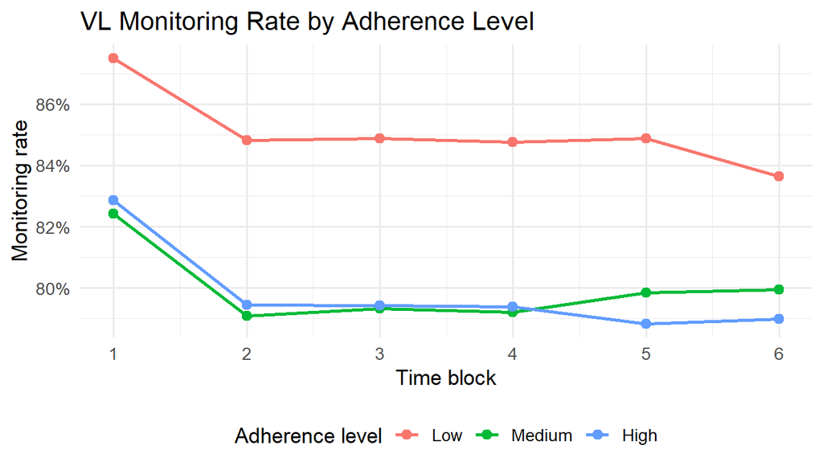

Figure 19: Viral load monitoring rate by adherence level over time in the expanded cohort.

```r
plot_monitoring_by_adherence(dat_full, K_full)
```

The monitoring frequency figure confirms that testing is informative: patients with low adherence tend to be monitored more frequently (clinicians order viral loads when they suspect poor adherence or treatment failure), while high-adherence patients have more routine testing schedules. This differential monitoring is what creates the gap between latent and detected failure rates.

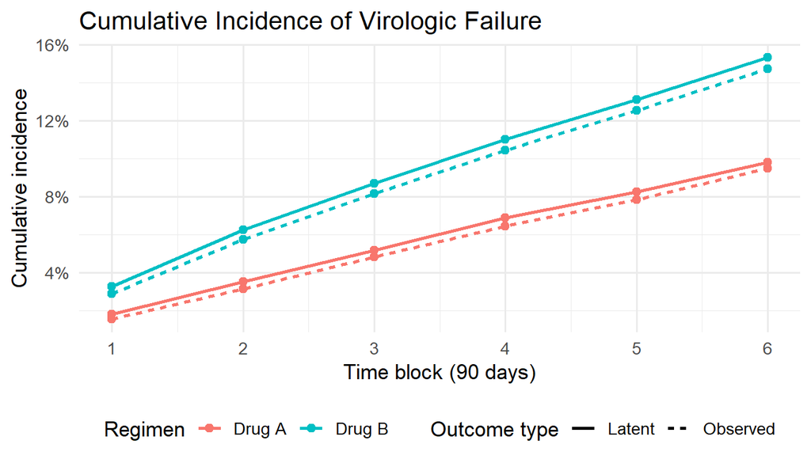

Figure 20: Cumulative incidence of virologic failure: latent (true biologic event) versus observed (detected by monitoring).

```r
plot_cumulative_incidence(dat_full, K_full, include_monitoring = TRUE)
```

#### 13.10.2.2 Targeting the latent outcome

To target the latent failure estimand, we replace $Y_t$ with $Y_t^*$ in the LTMLE data and include $M_t$ as a time-varying covariate (L-node). The estimator then adjusts for monitoring-induced selection rather than allowing monitoring to filter the outcome.

**Monitoring-adjusted LTMLE specification**

```r
# ── Monitoring-adjusted LTMLE ────────────────────────────────────────────
# When the DGP includes informative monitoring (Mvl_t) and treatment
# switching (S_t), the node ordering expands. Within each block t:
#   C_t → L_cd4_t, L_symp_t → S_t → A{t}_2, A{t}_3 → Mvl_t → Y_t
# Monitoring is always an L-node. Switching can be:
#   - L-node (treatment-policy): outcome is evaluated regardless of switch
#   - C-node (while-on-treatment): censoring at switch

# Build expanded node vectors using helper functions from ltmle_helpers.R
all_nodes_full <- make_ltmle_nodes(K = K_full, include_drug = TRUE,
                                    include_monitoring = TRUE,
                                    include_switching  = TRUE)

node_lists_full <- make_node_lists(K = K_full, include_drug = TRUE,
                                    include_monitoring = TRUE,
                                    include_switching  = TRUE,
                                    switch_as_censor = FALSE)
# With switching as L-node (treatment-policy strategy):
#   Lnodes now includes S_1..S_K and Mvl_1..Mvl_K
#   Cnodes remains C_1..C_K only

# ── Prepare the wide data for ltmle ──────────────────────────────────────
dat_full_wide <- encode_adherence_dummies(dat_full, K = K_full)
dat_full_wide <- enforce_absorbing_state(dat_full_wide, K_full)

# ── Targeting the latent outcome ──────────────────────────────────────────
# The observed outcome Y_t = Y*_t × M_t masks failures in unmonitored blocks.
# To target the latent failure risk (the oracle truth), swap Y_t with Y*_t:
for (tt in seq_len(K_full)) {
  dat_full_wide[[paste0("Y_", tt)]] <- dat_full_wide[[paste0("Ylatent_", tt)]]
}
# Now Y_1..Y_K contain latent (true) failure status.
# Mvl_t enters as a covariate: the estimator adjusts for monitoring-induced
# selection rather than allowing monitoring to filter the outcome.

# ── Build regime vectors and deterministic g-function ─────────────────────
regimes_full <- build_constant_regimes_3level(K = K_full, include_drug = TRUE)
det_g_full   <- make_det_g_3level(K_full)

# ── Fit with expanded covariates ──────────────────────────────────────────
fit_full <- ltmle(
  data   = dat_full_wide[, all_nodes_full],
  Anodes = node_lists_full$Anodes,
  Cnodes = node_lists_full$Cnodes,
  Lnodes = node_lists_full$Lnodes,
  Ynodes = node_lists_full$Ynodes,
  survivalOutcome = TRUE,
  abar   = regimes_full[["A0_1_high"]],
  deterministic.g.function = det_g_full,
  SL.library = "SL.glm",
  gbounds = c(0.001, 1),
  estimate.time = FALSE
)
# The point estimate now targets latent failure risk P(Y*_K = 1 | abar),
# not detected failure risk. Comparing to an analysis that uses observed Y
# illustrates the estimand mismatch from informative monitoring.
```

### 13.10.3 Informative censoring

Loss to follow-up is handled via inverse probability of censoring weighting (IPCW) within the LTMLE framework. The censoring indicator $C_t$ is included in the temporal node ordering at each block, and `ltmle` models the censoring mechanism as part of the estimation. Because censoring is typically informative in HIV cohorts — sicker patients are more likely to drop out, move away, or disengage from care — failing to account for it biases estimated risks downward, since the remaining sample overrepresents healthier survivors.

The `ltmle` package handles this automatically when `Cnodes` are specified. The censoring model is estimated alongside the treatment and outcome models, and the resulting estimates account for the informative dropout process. The same doubly robust property applies: the estimate is consistent if either the censoring/treatment model or the outcome model is correctly specified.

### 13.10.4 Treatment switching as an intercurrent event

Treatment switching is clinically common in ART cohorts. When a patient experiences virologic failure, intolerable side effects, or a new guideline-recommended option, clinicians may switch to an alternative regimen. How to handle switching is a key analytic decision that determines what the estimand means.

Two strategies are standard [following ICH E9(R1) terminology; International Council for Harmonisation (2019)]:

1. **Treatment-policy strategy:** Outcomes are evaluated regardless of whether the patient switched. The switching indicator $S_t$ is included as an L-node (time-varying covariate), and the estimand reflects what would happen in a population where switching follows its natural course. This is the default in most pragmatic analyses.
2. **While-on-treatment strategy:** Patients are censored at the time of switching. The switching indicator $S_t$ is included as a C-node, and the estimand reflects what would happen if patients remained on their initially assigned regimen. This requires modeling the censoring-at-switch mechanism and imposes additional positivity requirements.

The choice between strategies is driven by the clinical question. For forgiveness analysis, the treatment-policy strategy is typically preferred because it reflects real-world outcomes when patients can switch, and it avoids the positivity issues that arise from censoring at switch (which can eliminate a large fraction of the sample).

#### 13.10.4.1 Switching diagnostics

```r
if ("S_1" %in% names(dat_full)) {
  switch_rows <- list()
  for (tt in seq_len(K_full)) {
    s_col <- paste0("S_", tt)
    if (s_col %in% names(dat_full)) {
      for (drug_val in c(1, 0)) {
        sub <- dat_full[dat_full$A0 == drug_val, ]
        s_vals <- sub[[s_col]]
        valid <- !is.na(s_vals)
        switch_rows[[paste(tt, drug_val)]] <- data.frame(
          Block = tt,
          Drug = ifelse(drug_val == 1, "Drug A", "Drug B"),
          `N at risk` = sum(valid),
          `N switched` = sum(s_vals[valid] == 1),
          `Switch rate` = round(mean(s_vals[valid] == 1), 3),
          check.names = FALSE
        )
      }
    }
  }
  switch_df <- do.call(rbind, switch_rows)
  kable(switch_df, align = "rlrrr") |>
    kable_styling(bootstrap_options = c("striped", "condensed"), full_width = FALSE)
} else {
  cat("*Switching nodes (S_t) not present in expanded dataset.*")
}
```

Table 30: Treatment switching rates by initial regimen and time block.

|  | Block | Drug | N at risk | N switched | Switch rate |
| --- | --- | --- | --- | --- | --- |
| 1 1 | 1 | Drug A | 9563 | 152 | 0.016 |
| 1 0 | 1 | Drug B | 9987 | 133 | 0.013 |
| 2 1 | 2 | Drug A | 9182 | 138 | 0.015 |
| 2 0 | 2 | Drug B | 9416 | 139 | 0.015 |
| 3 1 | 3 | Drug A | 8830 | 120 | 0.014 |
| 3 0 | 3 | Drug B | 8887 | 120 | 0.014 |
| 4 1 | 4 | Drug A | 8463 | 123 | 0.015 |
| 4 0 | 4 | Drug B | 8426 | 120 | 0.014 |
| 5 1 | 5 | Drug A | 8128 | 126 | 0.016 |
| 5 0 | 5 | Drug B | 7987 | 87 | 0.011 |
| 6 1 | 6 | Drug A | 7805 | 117 | 0.015 |
| 6 0 | 6 | Drug B | 7581 | 104 | 0.014 |

**Node structure for treatment switching**

```r
# ── Treatment-policy strategy: S_t as L-node ─────────────────────────────
# Outcomes are evaluated regardless of switching.
node_lists_policy <- make_node_lists(K = K_full, include_drug = TRUE,
                                      include_monitoring = TRUE,
                                      include_switching  = TRUE,
                                      switch_as_censor = FALSE)
# S_t appears in Lnodes alongside Mvl_t, L_cd4_t, L_symp_t
# Cnodes contains only C_t (loss to follow-up)

# ── While-on-treatment strategy: S_t as C-node ──────────────────────────
# Patients are censored at the time of switching.
node_lists_wot <- make_node_lists(K = K_full, include_drug = TRUE,
                                   include_monitoring = TRUE,
                                   include_switching  = TRUE,
                                   switch_as_censor = TRUE)
# S_t now appears in Cnodes alongside C_t
# The estimand changes: now reflects outcome *if the patient had stayed
# on the initially assigned regimen* (a stronger, less realistic assumption)
```

# 14 Extended examples: switching, informative monitoring, and intercurrent longitudinal events

The primary analysis focuses on a simplified setting with complete outcome ascertainment and a clean adherence-outcome feedback structure. Real-world HIV data involve additional longitudinal processes that extend the framework. This appendix describes three such extensions.

## 14.1 Informative monitoring

Viral load testing often occurs more frequently when clinical concern is higher, so the measurement process can be endogenous to the longitudinal data-generating system rather than a neutral observation layer. When high-risk patients are monitored more intensively, ignoring the monitoring process can bias estimates of adherence-response relationships. One approach is to include monitoring indicators — such as whether viral load was measured in the current period and when the most recent measurement occurred — as time-varying covariates in the adjustment set. When monitoring is strongly informative, joint modeling of the observation and censoring processes may be necessary so that the analysis targets outcomes under explicitly defined monitoring and adherence processes rather than the observed mixture.

## 14.2 Switching and discontinuation

Regimen switching and discontinuation function as intercurrent events whose handling depends on the scientific question. If the question is about sustained viral suppression, switching may be part of the composite treatment strategy and should be incorporated into the intervention definition. If the question isolates the biological effect of the initial regimen, switching may be treated as a censoring event. If the goal is comparative effectiveness inclusive of switching behavior, switching is part of the natural course. Discontinuation definitions that require sustained off-treatment gaps carry the risk of immortal follow-up, because patients who fail and restart treatment may be misclassified. Each framing implies a different causal estimand and different identification and estimation requirements; clarity about the intercurrent event strategy is essential before estimating any adherence-response or comparative effectiveness quantity.

## 14.3 How LTMLE and LMTP help untangle these processes

LTMLE is well suited to intervention-defined risks under static or dynamic treatment rules in the presence of time-varying confounding, time-varying censoring, and longitudinal outcomes. When the target intervention specifies adherence and monitoring exactly, LTMLE’s sequential regression and targeting structure handles the full time-varying adjustment consistently. LMTP is useful when the intervention of interest is more feasible and depends on the natural treatment value: shifting adherence relative to its observed level, mapping adherence to a reference distribution, or imposing realistic perturbations rather than deterministic replacement. Both approaches require explicit specification of the target intervention and careful attention to positivity. For comparative questions — such as whether regimen 1 is superior to comparator regimens in real-world use — a natural-course comparison allows adherence, monitoring, and switching to evolve as observed under each regimen. If the question instead concerns whether regimen differences persist under a common adherence pattern, an LMTP can map both regimens to the same reference adherence distribution. If the question concerns the effect of delaying or preventing switching after virologic worsening, LTMLE or history-indexed g-methods can be used to define intervention-specific counterfactual risks over future treatment trajectories.

## References

Bang, Heejung, and James M. Robins. 2005. “Doubly Robust Estimation in Missing Data and Causal Inference Models.” *Biometrics* 61 (4): 962–73. https://doi.org/10.1111/j.1541-0420.2005.00377.x.

Bangsberg, David R. 2006. “Less Than 95% Adherence to Nonnucleoside Reverse-Transcriptase Inhibitor Therapy Can Lead to Viral Suppression.” *Clinical Infectious Diseases* 43 (7): 939–41. https://doi.org/10.1086/507526.

Dang, Laurie E., Sara Tagarés, Kimberly W. Hagberg, Jie Mak, Susan S. Jick, Florin Vaida, Mark J. van der Laan, and Maya L. Petersen. 2023. “A Causal Roadmap for Generating High-Quality Real-World Evidence.” *Journal of Clinical and Translational Science* 7 (1): e212. https://doi.org/10.1017/cts.2023.635.

Díaz, Iván, Nima S. Hejazi, Kara E. Rudolph, and Mark J. van der Laan. 2021. “Causal Mediation Analysis for Stochastic Interventions.” *Journal of the Royal Statistical Society: Series B (Statistical Methodology)* 83 (3): 422–44. https://doi.org/10.1111/rssb.12362.

Díaz, Iván, Nicholas Williams, Katherine L. Hoffman, and Edward J. Schenck. 2021. “Nonparametric Causal Effects Based on Longitudinal Modified Treatment Policies.” *Journal of the American Statistical Association*. https://doi.org/10.1080/01621459.2021.1955691.

———. 2023. “Nonparametric Causal Effects Based on Longitudinal Modified Treatment Policies.” *Journal of the American Statistical Association* 118 (542): 846–57. https://doi.org/10.1080/01621459.2021.1955691.

Hejazi, Nima S., Kara E. Rudolph, and Iván Díaz. 2023. “Crumble: An R Package for Interventional Mediation Analysis.”

Hernán, Miguel A., and James M. Robins. 2020. *Causal Inference: What If*. Boca Raton: Chapman & Hall/CRC. https://www.hsph.harvard.edu/miguel-hernan/causal-inference-book/.

International Council for Harmonisation. 2019. “ICH E9(R1) Addendum on Estimands and Sensitivity Analysis in Clinical Trials to the Guideline on Statistical Principles for Clinical Trials.” ICH Harmonised Guideline. https://database.ich.org/sites/default/files/E9-R1_Step4_Guideline_2019_1203.pdf.

Laan, Mark J. van der, and Susan Gruber. 2012. “Targeted Minimum Loss Based Estimation of Causal Effects of Multiple Time Point Interventions.” *The International Journal of Biostatistics* 8 (1). https://doi.org/10.1515/1557-4679.1370.

Laan, Mark J. van der, and Daniel Rubin. 2006. “Targeted Maximum Likelihood Learning.” *The International Journal of Biostatistics* 2 (1). https://doi.org/10.2202/1557-4679.1043.

Lendle, Samuel D., Joshua Schwab, Maya L. Petersen, and Mark J. van der Laan. 2017. “Ltmle: An R Package Implementing Targeted Minimum Loss-Based Estimation for Longitudinal Data.” *Journal of Statistical Software* 81 (1): 1–21. https://doi.org/10.18637/jss.v081.i01.

Orkin, Chloe, Keikawus Arasteh, María Jesús Hernández-Mora, et al. 2021. “Long-Acting Cabotegravir and Rilpivirine After Oral Induction for HIV-1 Infection.” *New England Journal of Medicine* 382: 1124–35. https://doi.org/10.1056/NEJMoa1909512.

Overton, Edgar Turner, Gary Richmond, Giuliano Rizzardini, et al. 2021. “Long-Acting Cabotegravir and Rilpivirine Dosed Every 2 Months in Adults with HIV-1 Infection (ATLAS-2M), 48-Week Results.” *The Lancet* 396: 1994–2005. https://doi.org/10.1016/S0140-6736(20)32666-0.

Paterson, David L., Susan Swindells, Jeffrey Mohr, Michelle Brester, Emanuel N. Vergis, Cheryl Squier, Marilyn M. Wagener, and Nina Singh. 2000. “Adherence to Protease Inhibitor Therapy and Outcomes in Patients with HIV Infection.” *Annals of Internal Medicine* 133 (1): 21–30. https://doi.org/10.7326/0003-4819-133-1-200007040-00004.

Petersen, Maya, Joshua Schwab, Susan Gruber, Nello Blaser, Michael Schomaker, and Mark van der Laan. 2014. “Targeted Maximum Likelihood Estimation for Dynamic and Static Longitudinal Marginal Structural Working Models.” *Journal of Causal Inference* 2 (2): 147–85. https://doi.org/10.1515/jci-2013-0007.

Robins, James M. 1986. “A New Approach to Causal Inference in Mortality Studies with a Sustained Exposure Period—Application to Control of the Healthy Worker Survivor Effect.” *Mathematical Modelling* 7 (9): 1393–1512. https://doi.org/10.1016/0270-0255(86)90088-6.

Robins, James M., Miguel A. Hernán, and Babette Brumback. 2000. “Marginal Structural Models and Causal Inference in Epidemiology.” *Epidemiology* 11 (5): 550–60. https://doi.org/10.1097/00001648-200009000-00011.

Robins, James M., and Thomas S. Richardson. 2010. “Alternative Graphical Causal Models and the Identification of Direct Effects.” In *Causality and Psychopathology: Finding the Determinants of Disorders and Their Cures*, edited by Patrick E. Shrout, 103–58. Oxford University Press.

Rosenblum, Michael, and Mark J. van der Laan. 2010. “Targeted Maximum Likelihood Estimation of the Parameter of a Marginal Structural Model.” *The International Journal of Biostatistics* 6 (2). https://doi.org/10.2202/1557-4679.1238.

Swindells, Susan, Jaime-Federico Andrade-Villanueva, Gary J. Richmond, Giuliano Rizzardini, et al. 2020. “Long-Acting Cabotegravir and Rilpivirine for Maintenance of HIV-1 Suppression.” *New England Journal of Medicine* 382: 1112–23. https://doi.org/10.1056/NEJMoa1904398.

VanderWeele, Tyler J., and Peng Ding. 2017. “Sensitivity Analysis in Observational Research: Introducing the E-Value.” *Annals of Internal Medicine* 167 (4): 268–74. https://doi.org/10.7326/M16-2607.

Vrijens, Bernard, Sabina De Geest, Dyfrig A. Hughes, Kardas Przemyslaw, Jonathan Demonceau, Albrecht Jacobs, Antonio Cherubini, et al. 2012. “A New Taxonomy for Describing and Defining Adherence to Medications.” *British Journal of Clinical Pharmacology* 73 (5): 691–705. https://doi.org/10.1111/j.1365-2125.2012.04167.x.

Williams, Nicholas, and Iván Díaz. 2023. “Lmtp: An R Package for Estimating the Causal Effects of Modified Treatment Policies.” *Observational Studies* 9: 103–22. https://doi.org/10.1353/obs.2023.0019.

Zheng, Wenjing, and Mark J. van der Laan. 2011. “Cross-Validated Targeted Minimum-Loss-Based Estimation.” In *Targeted Learning: Causal Inference for Observational and Experimental Data*, edited by Mark J. van der Laan and Sherri Rose, 459–74. New York, NY: Springer. https://doi.org/10.1007/978-1-4419-9782-1_27.